# Chap7.1

Mijeong Kim

```r
library(tsibble)
library(tsibbledata)
library(tibble)
library(dplyr)
library(knitr)
library(ggplot2)
library(fpp3)
library(fpp2)
library(seasonal)
library(feasts)
```

# 7. Time series regression models

#### 회귀 모델이란?

이 장에서는 **회귀(regression) 모델**을 통해 시계열 예측을 수행하는 방법을 다룬다.  
회귀 모델의 기본 개념은, 예측하고자 하는 시계열 `y`가 하나 이상의 다른 시계열 변수 `x`들과 **선형적인 관계**를 가진다고 가정하는 것이다.

#### 예시

- 월간 매출(`y`)을 광고비(`x`)로 예측
- 일일 전력 수요(`y`)를 기온(`x₁`)과 요일(`x₂`)을 이용하여 예측

#### 용어 정리

| 용어 | 의미 |
| --- | --- |
| `y` | 예측 대상 변수 (forecast variable) ※ 종속변수, 반응변수라고도 함 |
| `x` | 예측 변수 (predictor variables) ※ 독립변수, 설명 변수라고도 함 |

이 책에서는 일관성을 위해  
- `y`는 **forecast variable**  
- `x`는 **predictor variables**로 표현한다.

## 7.1 The linear model

### 단순 선형 회귀 모델

가장 단순한 형태의 회귀 모델은 **예측 대상 변수 `y`**와 **하나의 예측 변수 `x`** 사이의 **선형 관계**를 가정한다.

회귀식:

$$y_t = \beta_0 + \beta_1 x_t + \varepsilon_t$$

- $\beta_0$: **절편 (intercept)**  
  → `x = 0`일 때 예측되는 `y` 값
- $\beta_1$: **기울기 (slope)**  
  → `x`가 1 증가할 때 `y`의 평균 변화량
- $\varepsilon_t$: **오차항 (error term)**  
  → 실제 관측값과 회귀선 사이의 차이

#### 해석 및 특징

- 실제 관측값들은 직선 위에 정확히 위치하지 않고, 직선 주변에 **흩어져 분포**한다.
- 오차항 $\varepsilon_t$는 **모델에서 설명되지 않은 요인**들을 포함하며, 이는 **실수**가 아닌 **불확실성이나 외부 변수**의 영향을 의미한다.
- 따라서 $y_t$는 두 부분으로 구성된다:
  - **설명된 부분**: $\beta_0 + \beta_1 x_t$
  - **오차 또는 무작위성**: $\varepsilon_t$

### Example: US consumption expenditure

그림 7.2는 **미국의 실질 개인 소비 지출($y$)**과 **실질 개인 가처분 소득($x$)**의 분기별 증감률(성장률) 시계열을 보여준다. 자료 기간은 1970년 1분기부터 2019년 2분기까지이다.

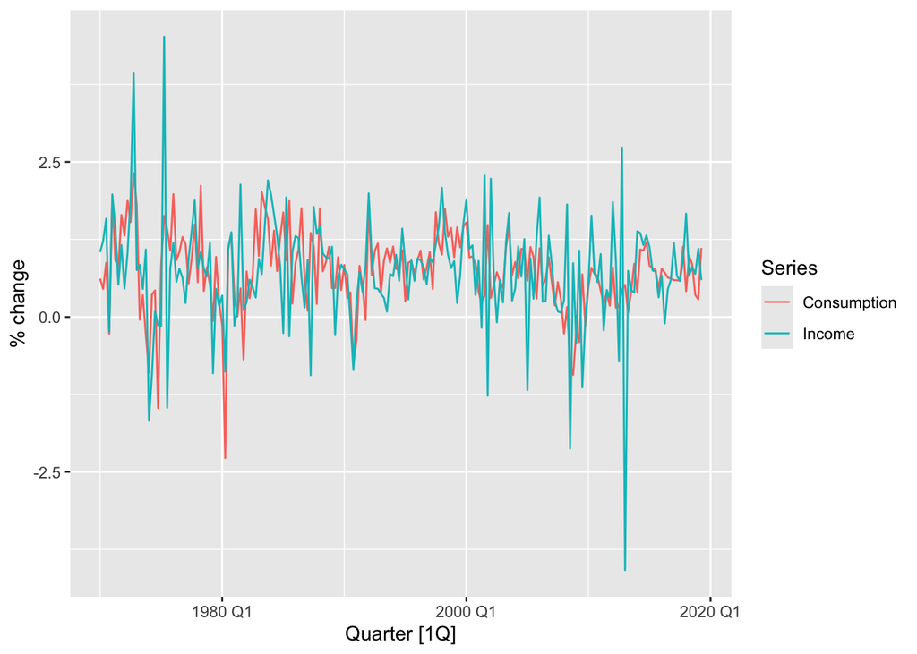

```r
us_change |>
  pivot_longer(c(Consumption, Income), names_to="Series") |>
  autoplot(value) +
  labs(y = "% change")
```

Figure 7.2: Percentage changes in personal consumption expenditure and personal income for the US.

#### 회귀식 및 시각화

그림 7.3은 **소득 변화(`x_t`)에 따른 소비 변화(`y_t`)**의 **산점도(scatter plot)**와 함께, **추정된 회귀선**을 보여준다.

#### 추정된 회귀식:

$$\hat{y}_t = 0.54 + 0.27x_t$$

- $\hat{y}_t$: 예측된 소비 변화  
  (모델에 의해 예측된 값을 의미하기 위해 “hat” 표기 사용)
- 0.54: 절편 (기본 소비 변화)
- 0.27: 기울기 (소득변화가 1 단위 증가할 때 소비의 평균 증가량)

#### 해석

- 소득 변화가 클수록 소비 변화도 증가하는 **양의 선형 관계**가 존재함
- $\hat{y}_t$는 소득 변화 `x_t`를 기반으로 예측된 소비 변화값을 의미함

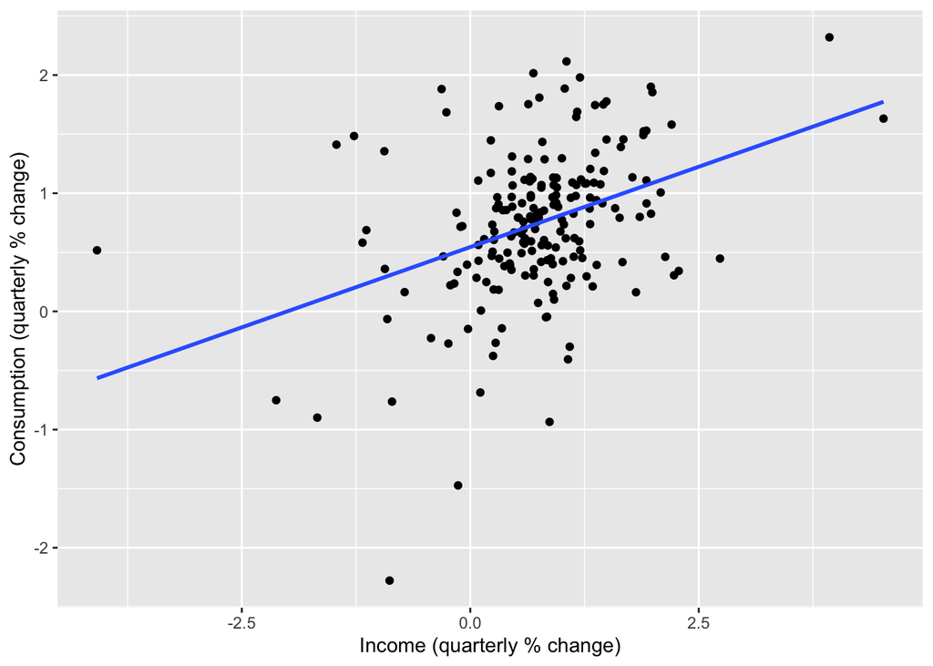

```r
us_change |>
  ggplot(aes(x = Income, y = Consumption)) +
  labs(y = "Consumption (quarterly % change)",
       x = "Income (quarterly % change)") +
  geom_point() +
  geom_smooth(method = "lm", se = FALSE)
```

Figure 7.3: Scatterplot of quarterly changes in consumption expenditure versus quarterly changes in personal income and the fitted regression line.

이 방정식은 TSLM() 함수를 사용하여 추정된다.

```r
us_change |>
  model(TSLM(Consumption ~ Income)) |>
  report()
```

```
## Series: Consumption
## Model: TSLM
##
## Residuals:
##      Min       1Q   Median       3Q      Max
## -2.58236 -0.27777  0.01862  0.32330  1.42229
##
## Coefficients:
##             Estimate Std. Error t value Pr(>|t|)
## (Intercept)  0.54454    0.05403  10.079  < 2e-16 ***
## Income       0.27183    0.04673   5.817  2.4e-08 ***
## ---
## Signif. codes:  0 '***' 0.001 '**' 0.01 '*' 0.05 '.' 0.1 ' ' 1
##
## Residual standard error: 0.5905 on 196 degrees of freedom
## Multiple R-squared: 0.1472,  Adjusted R-squared: 0.1429
## F-statistic: 33.84 on 1 and 196 DF, p-value: 2.4022e-08
```

#### TSLM() 함수와 회귀식

- 회귀식은 `TSLM()` 함수를 사용하여 추정된다.
- 해당 함수의 작동 원리는 7.2절에서 다룰 예정

#### 회귀선 해석

추정된 회귀식:

$$\hat{y}_t = 0.54 + 0.27x_t$$

- **기울기 0.27**  
  → `x`가 1단위 증가(= 가처분 소득이 1% 증가)할 때, `y`(소비 지출)는 평균 **0.27% 증가**
- **절편 0.54**  
  → `x = 0`일 때, `y`는 평균 **0.54% 증가**하는 것으로 예측됨

예:  
- `x = 1`일 경우 →  
$\hat{y} = 0.54 + 0.27 × 1 = 0.82$  
→ 소비 지출이 **0.82% 증가**할 것으로 예측됨

#### 절편의 역할

- `x = 0`이 실질적으로 의미가 있든 없든, **절편은 포함하는 것이 원칙**
- 절편이 없으면 기울기 값이 왜곡될 수 있음
- 단, 회귀선을 원점을 통과하게 해야 하는 특별한 목적이 있다면 절편을 제거할 수 있음

### 다중 선형 회귀

**두 개 이상의 예측 변수(predictor variables)**를 사용하는 회귀 모델을 **다중 선형 회귀(Multiple Linear Regression)**라고 한다.

#### 일반적인 수식:

$$y_t = \beta_0 + \beta_1 x_{1,t} + \beta_2 x_{2,t} + \dots + \beta_k
x_{k,t} + \varepsilon_t \tag{7.1}$$

- `y_t`: 예측 대상 변수 (forecast variable)
- `x_{1,t}, ..., x_{k,t}`: `k`개의 수치형 예측 변수
- $\beta_1, ..., \beta_k$: 각 예측 변수의 **한계 효과(marginal effect)**를 나타냄  
  → 다른 변수들의 영향을 통제한 후, 해당 변수의 기여 정도를 나타냄

#### 예시: 미국 소비 지출 예측

예측 변수:

- 실질 개인 가처분 소득 변화율
- 산업 생산 변화율
- 개인 저축 변화율
- 실업률 변화량

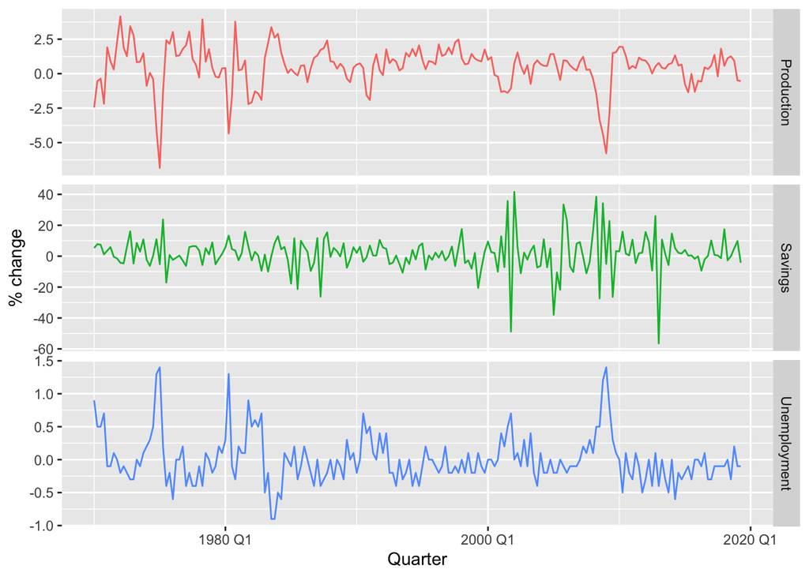

```r
us_change |>
  select(-Consumption, -Income) |>
  pivot_longer(-Quarter) |>
  ggplot(aes(Quarter, value, colour = name)) +
  geom_line() +
  facet_grid(name ~ ., scales = "free_y") +
  guides(colour = "none") +
  labs(y="% change")
```

Figure 7.4: Quarterly percentage changes in industrial production and personal savings and quarterly changes in the unemployment rate for the US over the period 1970Q1-2019Q2.

**그림 7.5는 다섯 개 변수의 산점도 행렬(scatterplot matrix)**을 보여준다.

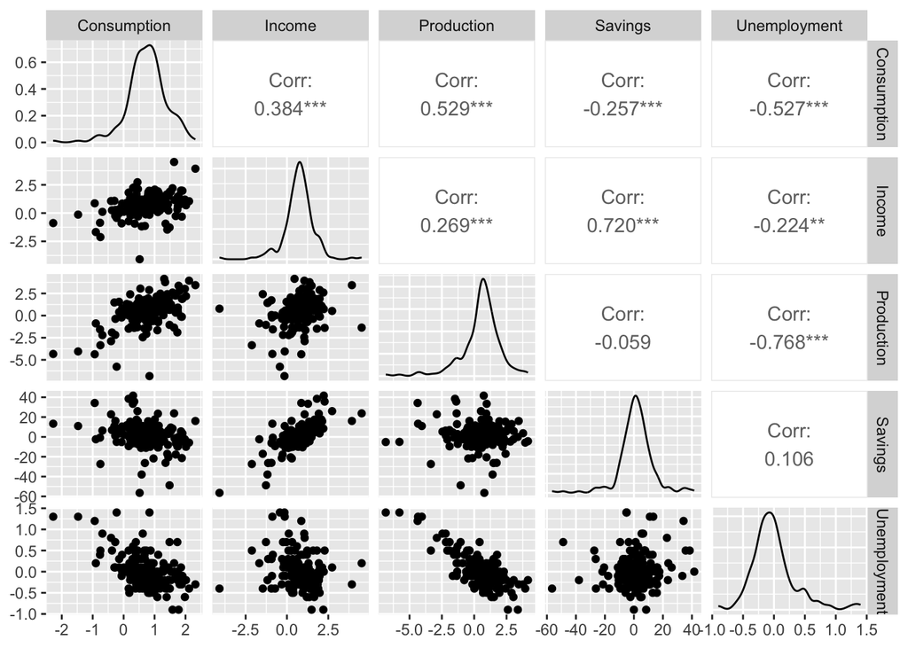

```r
us_change |>
  GGally::ggpairs(columns = 2:6)
```

### 회귀 모델의 기본 가정

선형 회귀 모델(식 7.1)을 사용할 때는 다음과 같은 가정을 내포하고 있다.

#### 1. 선형성 (Linearity)

- 예측 변수들과 예측 대상 변수 간의 관계가 **선형식(linear equation)**으로 근사될 수 있다고 가정한다.

#### 오차항(ε)의 가정

회귀식의 오차항 $\varepsilon_t$에 대해 다음과 같은 가정을 한다:

#### 2. 평균이 0

- $E(\varepsilon_t) = 0$  
  → 그렇지 않으면 예측값이 **체계적으로 편향(bias)**될 수 있음

#### 3. 자기상관 없음

- $\varepsilon_t$들은 **서로 독립적(autocorrelation 없음)**이어야 함  
  → 그렇지 않으면 데이터에 남아 있는 정보를 모델이 활용하지 못하게 됨

#### 4. 예측 변수들과 독립

- $\varepsilon_t$는 **예측 변수들과 관련이 없어야 함**  
  → 관련이 있다면 모델이 설명해야 할 정보가 오차에 남아 있다는 뜻

#### 5. 등분산성과 정규성 (권장 사항)

- $\varepsilon_t \sim N(0, \sigma^2)$  
  → 정규분포 및 일정한 분산 가정은 **예측 구간 생성**에 유리함

#### 예측 변수(x)의 비확률성 가정

- 실험 데이터에서는 예측 변수 `x`를 통제할 수 있지만,  
  **관측 데이터(observational data)**에서는 `x`도 관측값이므로 본질적으로 확률 변수일 수 있음
- 회귀 모델에서는 **`x`는 고정된 값(비확률 변수)**이라고 가정